# LBB9_NN

Ambiya Sang Aji

June 20, 2019

# LBB - Neural Network

Dalam Laporan ini akan dilakukan prediksi data fashion MNIST, yaitu adalah data gambar dengan size 28x28 pixel, berisikan data gambar related dengan fashion, dataset ini memiliki 10 kelas. kelas kelas tersebut adalah :

0. T shirt
1. Trouser
2. Pullover
3. Dress
4. Coat
5. Sandal
6. Shirt
7. Sneaker
8. Bag
9. Ankle Boot

Akan dicoba dilakukan image clasification dengan menggunakan model neural network dengan algoritma backpro dengan menggunakan package keras

# Read and Analyze Data

```r
train <- read.csv("fashionmnist/train.csv")
test <- read.csv("fashionmnist/test.csv")
```

```r
range(train$label)
```

```
## [1] 0 9
```

Akan dilakukan splitting data label.

```r
train_x <- train[,-1]
test_x <- test[,-1]
train_y <- train[,1]
test_y <- test[,1]
```

Data berisi data gradient black - white yang memiliki range 0-255, akan dilakukan scaling ke dalam range 0-1

```r
train_x <- train_x/255
test_x <- test_x/255
```

## Pembuatan Model

Set Arsitektur NN

```r
model <-  keras_model_sequential()
model %>%
  layer_dense(units = 128*8, activation =  "relu", input_shape =  c(784)) %>%
  layer_dropout(rate = 0.3) %>%
  layer_dense(units = 128*4, activation =  "relu") %>%
  layer_dropout(rate = 0.2) %>%
  layer_dense(units = 128*2, activation =  "relu") %>%
  layer_dropout(rate = 0.1) %>%
  layer_dense(units = 128, activation =  "relu") %>%
  layer_dropout(rate = 0.05) %>%
  layer_dense(units = 64, activation =  "relu") %>%
  layer_dense(units = 10, activation = "softmax")
```

Set Model Evaluasi.

```r
model %>%
  compile(
    loss = "categorical_crossentropy",
    optimizer = optimizer_adam(),
    metrics = c("accuracy")
  )
```

Melakukan Perubahan Format data sesuai dengan kebutuhan package.

```r
train_y <- to_categorical(train_y)
test_y <- to_categorical(test_y)
train_x <- as.matrix(train_x)
test_x <- as.matrix(test_x)
```

Fitting Model ke Data Train

```r
history <- model %>% fit(
  train_x, train_y,
  epochs = 15, batch_size = 200,
  validation_split = 0.2
)
```

Berikut adalah plot historical accuracy setiap epoch

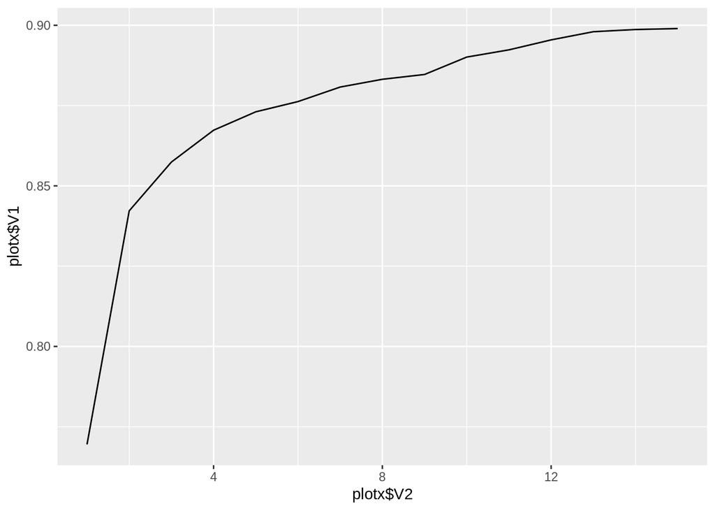

```r
plotx <- matrix(nrow=history$params$epochs, ncol = 2)
plotx[,1] <- history$metrics$acc
plotx[,2] <- seq.int(history$params$epochs)
plotx <- as.data.frame(plotx)
ggplot() +
  geom_line(data = plotx, aes(x=plotx$V2, y=plotx$V1))
```

Evaluasi Model

```r
model %>%
  evaluate(test_x,test_y)
```

```
## $loss
## [1] 0.2997137
##
## $acc
## [1] 0.8933
```

Selanjutnya akan dilihat secara detail confusion matrixnya.

```r
predict <- model %>%  predict_classes(test_x)
```

```r
categories <- c("T-shirt", "Trouser", "Pullover", "Dress", "Coat", "Sandal", "Shirt", "Sneaker", "Bag", "Boot")
predict <- factor(predict, labels=categories)
actual <- factor(test$label,labels=categories)
confusionMatrix(predict,actual)
```

```
## Confusion Matrix and Statistics
##
##           Reference
## Prediction T-shirt Trouser Pullover Dress Coat Sandal Shirt Sneaker Bag
##   T-shirt      871       1       14    15    0      0   163       0   4
##   Trouser        0     987        1     7    2      0     2       0   0
##   Pullover       7       0      728     4   45      1    30       0   6
##   Dress         16      10       13   938   29      0    21       0   2
##   Coat           0       0      103    16  858      0    54       0   1
##   Sandal         0       2        0     3    1    967     0      22   8
##   Shirt        101       0      137    16   64      0   722       0   6
##   Sneaker        1       0        0     0    0     22     0     932   5
##   Bag            4       0        4     1    1      1     8       0 967
##   Boot           0       0        0     0    0      9     0      46   1
##           Reference
## Prediction Boot
##   T-shirt     1
##   Trouser     0
##   Pullover    0
##   Dress       0
##   Coat        0
##   Sandal     10
##   Shirt       0
##   Sneaker    26
##   Bag         0
##   Boot      963
##
## Overall Statistics
##
##                Accuracy : 0.8933
##                  95% CI : (0.8871, 0.8993)
##     No Information Rate : 0.1
##     P-Value [Acc > NIR] : < 2.2e-16
##
##                   Kappa : 0.8814
##
##  Mcnemar's Test P-Value : NA
##
## Statistics by Class:
##
```

[output cut: 12 more lines]

```
## Pos Pred Value             0.9116      0.8314        0.9546       0.6902
## Neg Pred Value             0.9931      0.9842        0.9963       0.9690
## Prevalence                 0.1000      0.1000        0.1000       0.1000
## Detection Rate             0.0938      0.0858        0.0967       0.0722
## Detection Prevalence       0.1029      0.1032        0.1013       0.1046
## Balanced Accuracy          0.9639      0.9193        0.9809       0.8430
##                      Class: Sneaker Class: Bag Class: Boot
## Sensitivity                  0.9320     0.9670      0.9630
## Specificity                  0.9940     0.9979      0.9938
## Pos Pred Value               0.9452     0.9807      0.9450
## Neg Pred Value               0.9925     0.9963      0.9959
## Prevalence                   0.1000     0.1000      0.1000
## Detection Rate               0.0932     0.0967      0.0963
## Detection Prevalence         0.0986     0.0986      0.1019
## Balanced Accuracy            0.9630     0.9824      0.9784
```